# Bank Campaign

- Introduction
- Data Wrangling
- Exploratory Data Analysis
- Conclusions

# Introduction

## Our Data

The data is related with direct marketing campaigns of a Portuguese banking institution. The marketing campaigns were based on phone calls. Often, more than one contact to the same client was required, in order to access if the product (bank term deposit) would be (or not) subscribed.

## Data's Information

The data Consists of 16 Feature and one Target Variable, the data's attributes in detail:

*Bank client data:*

1. **age** (numeric)
2. **job**: type of job (categorical: "admin.","unknown","unemployed","management","housemaid","entrepreneur", "student","blue-collar","self-employed","retired","technician","services")
3. **marital** : marital status (categorical: "married","divorced","single"; note: "divorced" means divorced or widowed)
4. **education** : (categorical: "unknown","secondary","primary","tertiary")
5. **default** : has credit in default? (binary: "yes","no")
6. **balance** (numeric): average yearly balance, in euros
7. **housing**: has housing loan? (binary: "yes","no")
8. **loan**: has personal loan? (binary: "yes","no")

*Related with the last contact of the current campaign:*

1. **contact**: contact communication type (categorical: "unknown","telephone","cellular")
2. **day**: last contact day of the month (numeric)
3. **month**: last contact month of year (categorical: "jan", "feb", "mar", ..., "nov", "dec")
4. **duration**: last contact duration, in seconds (numeric)

*Other attributes:*

1. **campaign**: number of contacts performed during this campaign and for this client (numeric, includes last contact)
2. **pdays**: number of days that passed by after the client was last contacted from a previous campaign (numeric, -1 means client was not previously contacted)
3. **previous**: number of contacts performed before this campaign and for this client (numeric)
4. **poutcome**: outcome of the previous marketing campaign (categorical: "unknown","other","failure","success")

*output variable (desired target):*

1. **y**: has the client subscribed a term deposit? (binary: "yes","no")

## Our Goal

Simply we need to find what features affect a client subscribtion. as we invistegate the data we will try to unfold it's secrets and try to find the best strategy for a campaign to get more subscribers.

## Data Wrangling

```python
# Load the data
df = pd.read_csv('campaign.csv', names=cols, header=0)
df.head(5)
```

|  | age | job | marital_status | education | has_credit | balance | housing_loan | personal_loan | contact_type | lastc_day | lastc_month | lastc_duration | contact_count | passed_days | past_contacts | past_out | subscribed |
| --- | --- | --- | --- | --- | --- | --- | --- | --- | --- | --- | --- | --- | --- | --- | --- | --- | --- |
| 0 | 58 | management | married | tertiary | no | 2143 | yes | no | unknown | 5 | may | 261 | 1 | -1 | 0 | unknown | 1 |
| 1 | 44 | technician | single | secondary | no | 29 | yes | no | unknown | 5 | may | 151 | 1 | -1 | 0 | unknown | 1 |
| 2 | 33 | entrepreneur | married | secondary | no | 2 | yes | yes | unknown | 5 | may | 76 | 1 | -1 | 0 | unknown | 1 |
| 3 | 47 | blue-collar | married | unknown | no | 1506 | yes | no | unknown | 5 | may | 92 | 1 | -1 | 0 | unknown | 1 |
| 4 | 33 | unknown | single | unknown | no | 1 | no | no | unknown | 5 | may | 198 | 1 | -1 | 0 | unknown | 1 |

#### Comments :

We will invetigate furthrer to make sure our data is clean before we make any visualization or conclusions.

## Data Cleaning

3766 clients are recorded to make a negative value per year, This is just not possible. I will try to replace these values with the mean. However the mean is not that accurate so to compensate i will try to find the mean for specific group of client features.

I choose to plot incomes with over 500 to see the relationship with other client's features

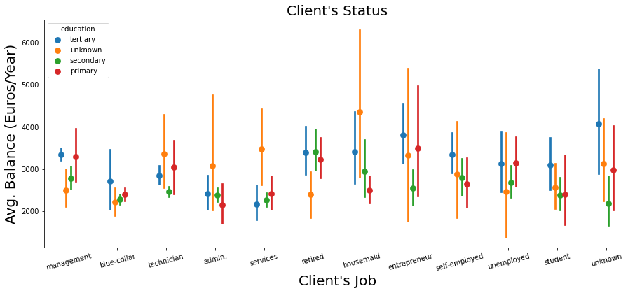

```python
# Figure axis
fig, ax = plt.subplots(figsize=(15, 6))

# Plot Job, Marital Status and Balance all together
sns.pointplot(df_balance.job, df_balance.balance,
              hue=df_balance.education , linestyles='', dodge=0.3)

# Plot Customization
plt.xticks(rotation=15)
plt.title("Client's Status", fontsize=20)
plt.xlabel("Client's Job", fontsize=20)
plt.ylabel('Avg. Balance (Euros/Year)', fontsize=20)

plt.show()
```

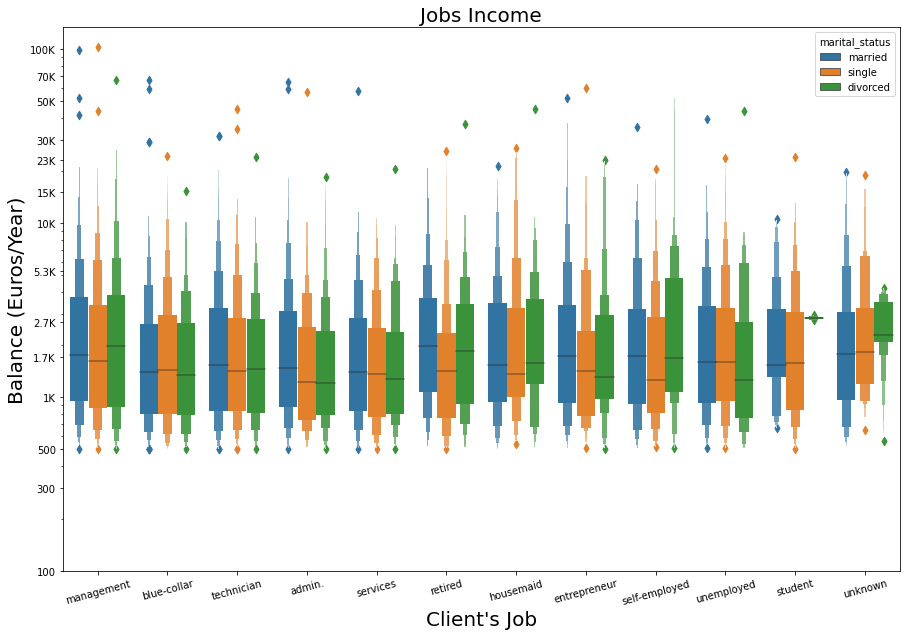

```python
# Figure axis
fig, ax = plt.subplots(figsize=(15, 10))

sns.boxenplot(df_balance.job, df_balance.balance, hue=df_balance.marital_status)

# Plot Customizations
plt.xticks(rotation=15)
plt.xlabel("Client's Job", fontsize=20)
plt.ylabel('Balance (Euros/Year)', fontsize=20)
plt.title('Jobs Income', fontsize=20)
yticks = [100, 300, 500, 1e3, 1.7e3, 2.7e3, 5.3e3, 10e3, 15e3, 23e3, 30e3, 50e3, 70e3, 10e4]
ylabels = ['100', '300', '500', '1K', '1.7K', '2.7K', '5.3K', '10K', '15K', '23K', '30K', '50K', '70K', '100K']
plt.yscale('log')
plt.yticks(yticks, ylabels)

# Show Plot
plt.show()
```

It seems a bit off that some incomes are only 1 Euro per Year or even negtaive. This may be a case of a Missing not at Random values since this is a salary and highly paied clients might not want to reveal their salary. Clients may leave a misleadnig value in order not to reveal their salary.

I only replaced Negative values with mean of a specified group of features for the client.

## Exploratory Data Analysis

Now we are at the point in our investigation were we are interested in finding relationships between our features and the Target variable.

#### Related to the client

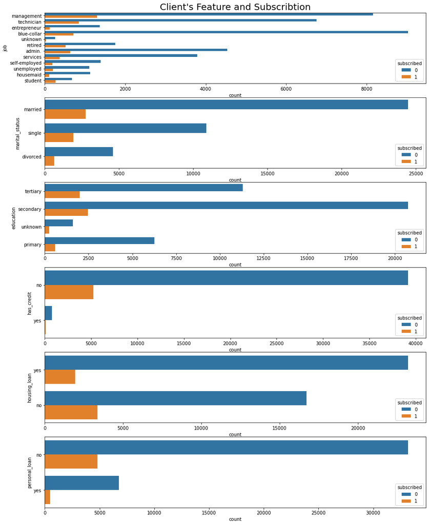

```python
fig, ax = plt.subplots(6, 1, figsize=(15, 20))

sns.countplot(y=df.job, hue=df.subscribed, ax=ax[0])
sns.countplot(y=df.marital_status, hue=df.subscribed, ax=ax[1])
sns.countplot(y=df.education, hue=df.subscribed, ax=ax[2])
sns.countplot(y=df.has_credit, hue=df.subscribed, ax=ax[3])
sns.countplot(y=df.housing_loan, hue=df.subscribed, ax=ax[4])
sns.countplot(y=df.personal_loan, hue=df.subscribed, ax=ax[5])

ax[0].set_title("Client's Feature and Subscribtion", fontsize=20)
plt.show()
```

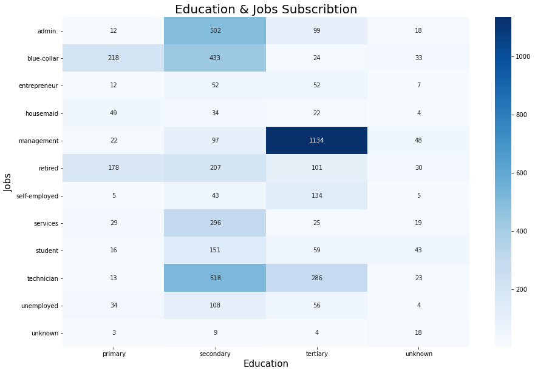

```python
# Figure Axes
fig, ax=plt.subplots(figsize=(15, 10))

# Plot Heat Map
sns.heatmap(counts, cmap=cmap, annot=True, fmt='d')

# Plot Customizations
plt.title("Education & Jobs Subscribtion", fontsize=20)
plt.xlabel("Education", fontsize=15)
plt.ylabel("Jobs", fontsize=15)

plt.show()
```

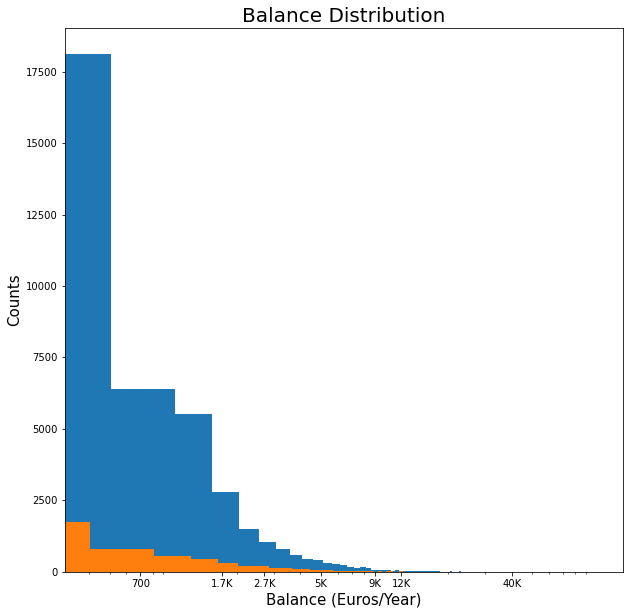

```python
fig, ax = plt.subplots(figsize=(10, 10))

# Plot Age Distribution
plt.hist(df[df.subscribed == 0].balance, bins=200)
plt.hist(df[df.subscribed == 1].balance, bins=200)

# Plot Customizations
plt.title('Balance Distribution', fontsize=20)
plt.xlabel('Balance (Euros/Year)', fontsize=15)
plt.xscale('log')
plt.ylabel('Counts', fontsize=15)
xticks = [700, 1.7e3, 2.7e3, 5e3, 9e3, 12e3, 40e3]
xlabels = ['700', '1.7K', '2.7K', '5K', '9K', '12K', '40K']
plt.xticks(xticks, xlabels)

# Show Plot
plt.show()
```

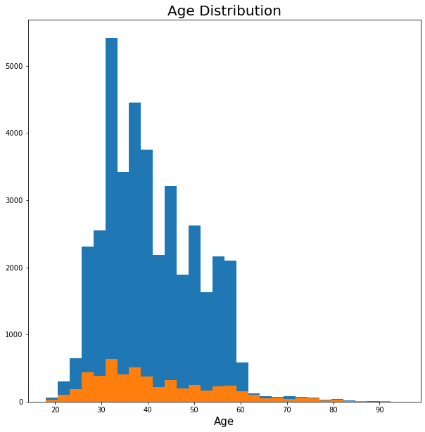

```python
fig, ax = plt.subplots(figsize=(10, 10))

# Plot Age Distribution
plt.hist(df[df.subscribed == 0].age, bins=30)
plt.hist(df[df.subscribed == 1].age, bins=30)

# Plot Customizations
plt.title('Age Distribution', fontsize=20)
plt.xlabel('Age', fontsize=15)

# Show Plot
plt.show()
```

Now we've seen that there is no special client treat that makes more subscribers, However some features have more subscribers than others like working in manegement or being married. Clients who finished to finish secondary Education have more subscribers than others, and having a housing loan seems to make clients refuse more the subscribtion.

### Related with the last contact of the current campaign:

Now we investigate the campaign's own techniques to drive clients.

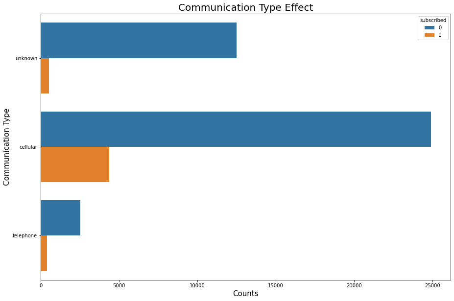

```python
# Figure Axes
fig, ax = plt.subplots(figsize=(15, 10))

# Plot Communication types
sns.countplot(y=df.contact_type, hue=df.subscribed, ax=ax);

# Plot Customizations
plt.title("Communication Type Effect", fontsize=20)
plt.xlabel('Counts', fontsize=15)
plt.ylabel('Communication Type', fontsize=15)

# Show
plt.show()
```

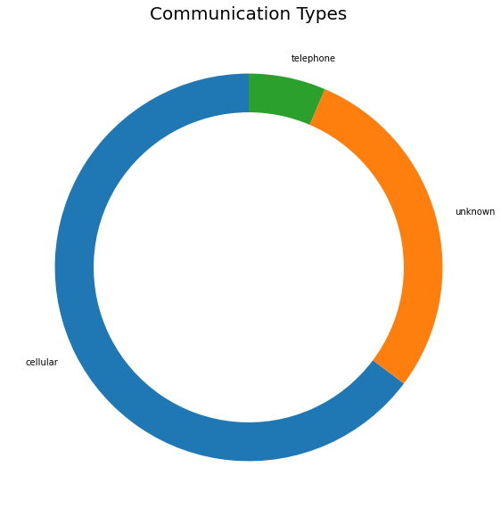

```python
communication_counts = df.contact_type.value_counts()


fig, ax = plt.subplots(figsize=(10, 10))
plt.pie(communication_counts, labels=communication_counts.index, startangle=90,  wedgeprops = {'width' : 0.2})

plt.title("Communication Types", fontsize=20)
plt.show()
```

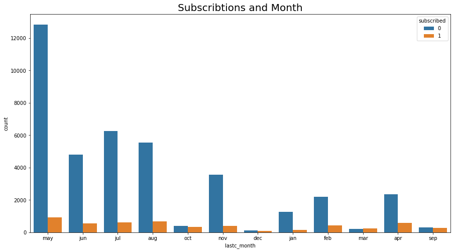

```python
fig, ax = plt.subplots(figsize=(15, 8))

sns.countplot(df.lastc_month, hue=df.subscribed)
plt.title('Subscribtions and Month', fontsize=20)

plt.show()
```

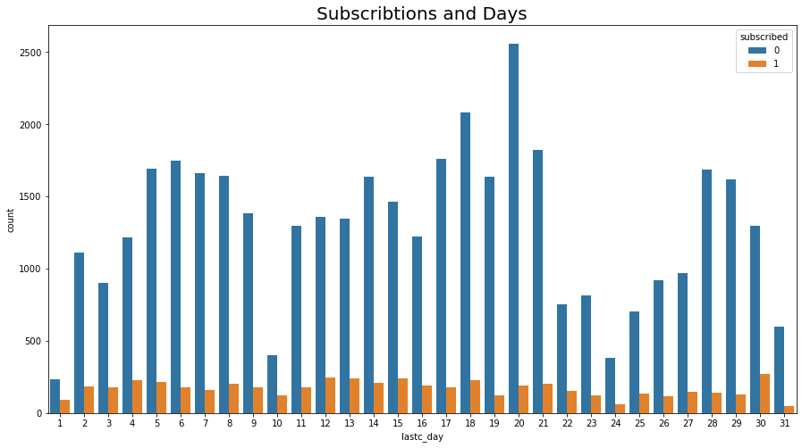

```python
fig, ax = plt.subplots(figsize=(15, 8))

sns.countplot(df.lastc_day, hue=df.subscribed)
plt.title('Subscribtions and Days', fontsize=20)

plt.show()
```

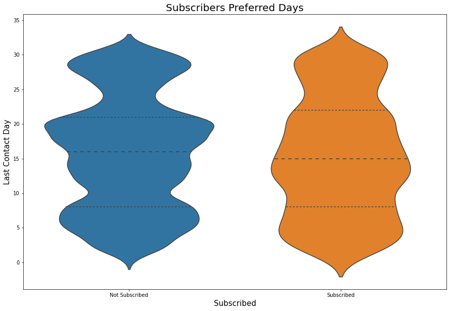

```python
fig, ax = plt.subplots(figsize=(15, 10))

sns.violinplot(x=df.subscribed, y=df.lastc_day, inner='quartile')

plt.title("Subscribers Preferred Days", fontsize=20)
plt.xlabel('Subscribed', fontsize=15)
plt.xticks([0, 1], ['Not Subscribed', 'Subscribed'])
plt.ylabel('Last Contact Day', fontsize=15)

plt.show()
```

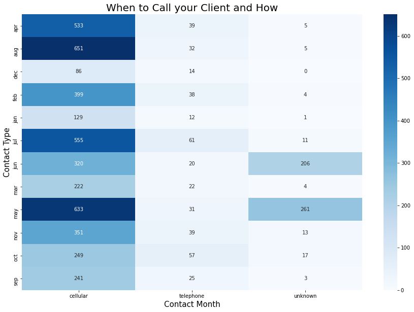

```python
fig, ax = plt.subplots(figsize=(15, 10))
sns.heatmap(counts, cmap=cmap, annot=True, fmt='d', ax=ax)
plt.title('When to Call your Client and How', fontsize=20)
plt.xlabel('Contact Month', fontsize=15)
plt.ylabel('Contact Type', fontsize=15)

plt.show()
```

### Other Attributes

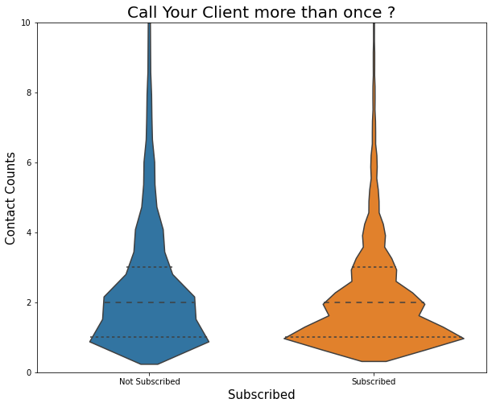

```python
fig, ax= plt.subplots(figsize=(10, 8))

sns.violinplot(y=df.contact_count, x=df.subscribed, ax=ax, inner='quartile')
plt.title("Call Your Client more than once ?", fontsize=20)
plt.xlabel("Subscribed", fontsize=15)
plt.xticks([0, 1], ["Not Subscribed", "Subscribed"])
plt.ylim(0, 10)
plt.ylabel("Contact Counts", fontsize=15)

plt.show()
```

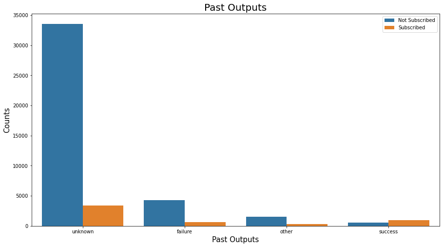

```python
# Figure Axes
fig, ax= plt.subplots(figsize=(15, 8))

# Plot Past outcomes
sns.countplot(x=df.past_out, hue=df.subscribed)
plt.title('Past Outputs', fontsize=20)
plt.ylabel('Counts', fontsize=15)
plt.xlabel('Past Outputs', fontsize=15)
plt.legend(['Not Subscribed', 'Subscribed'])

# Show
plt.show()
```

## Conclusions

The Data's imbalance seems to have a great impact on the investigation, However we found some interesting facts:

- `Manegment` & `Technician` People seems to subscribe more than other jobs
- Clients who have `Housing Load` & `Personal Loans` are more inclined to reject the subscribtion
- `Tertiary Education` has the most subscribers combined with a `Managemnt Job`
- Yes it is important when to call your client, more clients subscribed in the summer starting from MAY to August
- Contacting clients more than one time has an effect but to some extent.

#### Data Problems

- Balance Featutre seems to be noisy and misleading, i guess it is a case of Not Missing at Random where maybe clients with high salaries refuse to reveal their income
- Data's Imbalance seems to be a problem misleading the investigation.